# In class exercise: Week14 (partial solutions)

# Baby wald

Let $X=(X_i)_{i=1}^{\infty}$ be an iid sequence of random variables. Let $N$ be a random nonnegative integer that is independent of $X$. Suppose $X_1$ and $N$ have finite expectations. Prove that
$$\mathbb{E} \big( \sum_{i=1} ^N X_i \big) = \mathbb{E}N \mathbb{E} X_1$$

## Solution

Observe that

$$\sum_{i=1} ^N X_i = \sum_{n=0} ^{\infty}\sum_{i=1} ^n X_i\mathbf{1}[N=n].$$

Note that we take as convention that when $n=0$, we have the empty sum, which is zero. Since $N$ and the iid sequence $X$ are independent, we have that

$$\mathbb{E}(X_i \mathbf{1}[N=n] ) = \mathbb{E}(X_i) \mathbb{E}(\mathbf{1}[N=n] ) = \mathbb{E}(X_i) \mathbb{P}(N=n).$$
Thus taking expectations on both sides (and bring the expectation operator over an infinite sum) we have

$$\mathbb{E} \big( \sum_{i=1} ^N X_i \big) = \sum_{n=0} ^{\infty}\sum_{i=1} ^n \mathbb{E}(X_i) \mathbb{P}(N=n) = \mathbb{E}(X_1)\sum_{n=0}n\mathbb{P}(N=n) = \mathbb{E}(X_1) \mathbb{E}(N),$$

as desired.

# Tiling

- How would you do [Exercise 4](https://tsoo-math.github.io/ucl/QHW6.1-sols.html) analytically?
- What would you do if there is more than two tiles, and the tiles did not occur with equal probability?
- Use simulations to test your formula.

## Solutions

- Consider two tile types: a and b, of lengths $a$ and $b$, respectively. We can consider this an alternating renewal process: the working time is the time it remains in an a-tile, before switching to a b-tile, having service time, the time it remains in the b-tile. In order to compute the working time, we note that we spend time $a$ on each time we get an a-tile; thus by the Baby Wald result the working time is given by $aN_a$, where $N_a$ is geometric with parameter $p=\tfrac{1}{2}$. Similarly, the service time is given by $bN_b$, and again $N_b$ is just geometric with parameter $p=\tfrac{1}{2}$. Applying the theorem on alternating renewal processes we have

$$\lim_{t \to \infty} \mathbb{P}(\text{that we are on an a-tile at time } t) = \frac{\mathbb{E}( aN_a) }{\mathbb{E}( aN_a) + \mathbb{E}( bN_b) } = \frac{a}{a+b}$$

- Consider the case of three tiles $a$, $b$, and $c$ that occur with probabilities $p_a + p_b + p_c =1$. Again, we can treat this as an alternating renewal process. The working time is $aN_a$, where $N_a$ is now a geometric $1-p_a$. The service time is a bit more complicated, as remaining on a b-tile or a c-tile counts as service; the number of such tiles is again geometric $1-p_b-p_c = p_a$, but we really do need to use the Baby Wald, as the tiles could be or length $b$ or $c$, with probabilites $\tfrac{p_b}{p_b+p_c}$ and $\tfrac{p_c}{p_b+p_c}$ respectively, giving an expecting service time of

$$\big( b \cdot \tfrac{p_b}{p_b+p_c} + c \cdot \tfrac{p_c}{p_b+p_c} \big) \cdot \tfrac{1}{p_a}.$$

Thus

$$\lim_{t \to \infty} \mathbb{P}(\text{that we are on an a-tile at time } t) = \frac{\tfrac{a}{1-p_a}} { \tfrac{a}{1-p_a} + (b \cdot \tfrac{p_b}{p_b+p_c} + c \cdot \tfrac{p_c}{p_b+p_c} \big) \cdot \tfrac{1}{p_a} }.$$

- We test this formula in Python, with $a=1, b=\sqrt{2}, c=\pi$ and $p_a = 2/9$, $p_b=3/9$, and $p_c = 4/9$. We check the tile type at $t=300$, for a total of $1000$ independent times.

```python
import numpy as np

pa= 2/9
pb= 3/9
pc= 4/9

a=1
b=np.sqrt(2)
c=np.pi

def type():
  x=a
  u=np.random.uniform()
  if (u > pa and u < pa+pb):
    x=b
  if (u > pa+pb):
    x=c
  return x

def tile(t):
  ctile = type()
  tlength = ctile
  while(t > tlength):
    ctile = type()
    tlength = tlength + ctile
  return ctile

y = [tile(300) for _ in range(1000)  ]

freq = np.unique(y,return_counts = True)

print(freq)
```

```
## (array([1.        , 1.41421356, 3.14159265]), array([125, 228, 647], dtype=int64))
```

```python
tile1 = (1/1000)*freq[1][0]


tile1theory =   (a/(1-pa)) / (    a/(1-pa)    +  (b*(pb/(pb+pc)) +c *(pc/(pb + pc)))*(1/pa)                   )
print(tile1 - tile1theory      )
```

```
## 0.018667988819657297
```

# Size-biased intervals (simulation discussed in previous week)

Let $\Pi$ be a Poisson point process on $[0, \infty)$. Pick a (large) number, say $x=\sqrt{2} + 100$. Find the smallest interval $(A,B)$ such that $x \in (A,B)$, and $A$ and $B$ are points of $\Pi$, thus $B$ is the next arrival after $A$.

- Find the distribution of $S=B - A$.
- Is $S$ exponentially distributed? Explain.
- Do simulations to confirm your findings.

## Solutions

Consider a Poisson process of intensity $\lambda$

- We already know from the memoryless property that $B-x$ is still exponentially distributed with rate $\lambda$. It is not hard to argue from [reversibility](https://tsoo-math.github.io/ucl/QHW8.1.html) that $x-A$ is also exponentially distributed with rate $\lambda$.

One can also think about generating a two-sided Poisson process on $(-\infty, -\infty)$, this can be accomplished by putting together two independent Poisson processes on $(0, \infty)$ glued at $0$, where one is flipped.

- We see that $S$ has actually the sum of two independent exponentials.
- We can also see this in the following Python code, where we take $\lambda$=1:

```python
# Poisson arrivals just past the end time

def pois(end):
  T= np.array([np.random.exponential()])
  while(T[-1]<end):
    T = np.append(T, T[-1] + np.random.exponential())
  return T

def find(times,x):
  n=0
  while(x > times[n]):
    n = n+1
  return (times[n] - times[n-1])

print(find(pois(200), 100+np.sqrt(2) ))
```

```
## 1.2188956938953623
```

```python
y = [find(pois(200), 100+np.sqrt(2) ) for _ in range(5000)  ]

print(np.mean(y))
```

```
## 2.0200540996767087
```

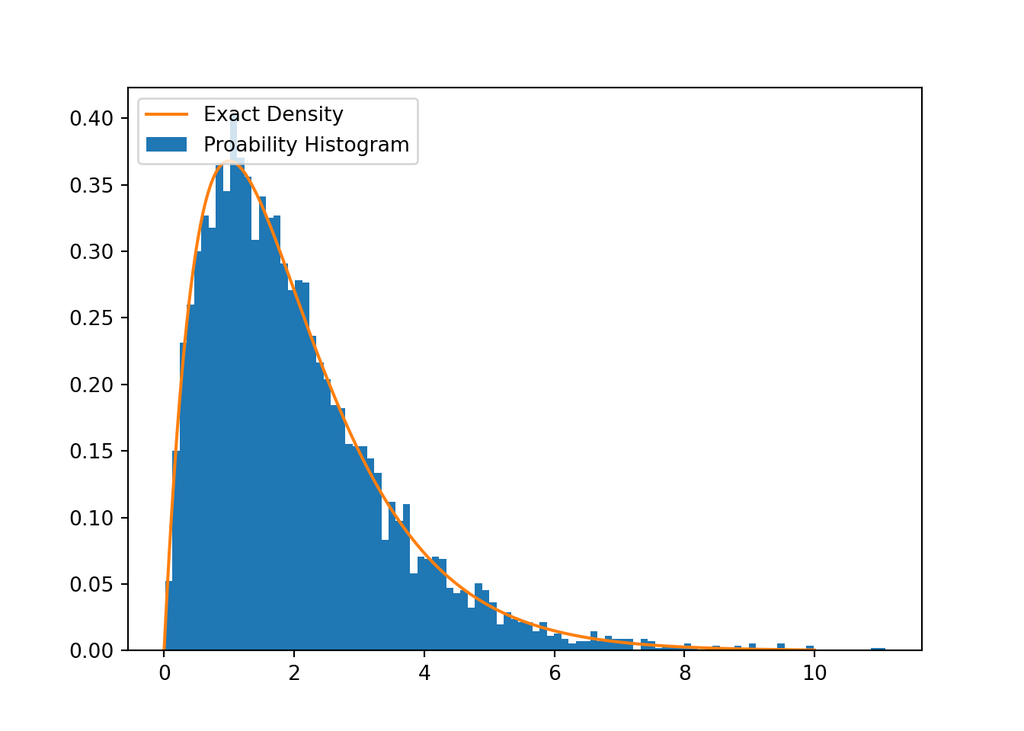

```python
import matplotlib.pyplot as plt
supress=plt.hist(y, bins = 100, density=True, label='Proability Histogram')
t=np.linspace(0,10,num=1000)
plt.plot(t,t*np.exp(-1*t), label='Exact Density')
plt.legend(loc='upper left')
plt.show()
```

# Size-biased intervals (stochastic domination)

See these [notes](http://ben-israel.rutgers.edu/711/Ross-Inspection.pdf)

# Endnotes

- Version: 29 November 2022
- [Rmd Source](https://tsoo-math.github.io/ucl3/week14-2022-sols.Rmd)